# Egzaminas

Kornelijus Samsonas

**Reikalingi užduotims paketai**

```r
library(car)
library(dynlm)
library(fpp)
```

# 1 užduotis

**Teorinis skirstinys**

```r
x1<-rnorm(n=1, mean = 3, sd=2)
x2<-rnorm(n=1, mean = -1, sd=3)
x<- x1+x2
```

# 2 užduotis

**1.**

**Nuskaitome duomenis.**

```r
data1 <- read.csv2("data_b.csv", header = TRUE)

data3<-data1[-c(416:422),]
```

**Apžvelgiame duomenis**

```r
head(data3)
```

```
##    islaidosVaisiams  butinosIslaidos          pajamos rajonoId
## 1  0.55264716607673  14.083383988741 27.1976217672389        2
## 2 0.352043570132186 13.3340536630728 9.23356048254358        1
## 3  0.41054439096652   5.444672968536 9.32350585248842        1
## 4 0.609335946811592 13.4877843946138 30.3525419571229        1
## 5 0.620213786386003 13.9682753211176 30.6464386758047        2
## 6 0.390109892744539 11.7340601203773  12.107559010339        3
##   atstumasIkiParduotuves
## 1       1464.66699771618
## 2       1610.16704945958
## 3       1553.04420636911
## 4       1391.91687372238
## 5       1335.35514006074
## 6       860.981545754901
```

```r
sum(data3 == "NAN")
```

```
## [1] 5
```

Matome, kad yra 5 trūkstamos reikšmes, reikia jas pašalinti. b)

**Pašaliname trūkstamas reikšmes**

```r
data3[data3 == "NAN"] <- NA
data2 <- na.omit(data3)
head(data2)
```

```
##    islaidosVaisiams  butinosIslaidos          pajamos rajonoId
## 1  0.55264716607673  14.083383988741 27.1976217672389        2
## 2 0.352043570132186 13.3340536630728 9.23356048254358        1
## 3  0.41054439096652   5.444672968536 9.32350585248842        1
## 4 0.609335946811592 13.4877843946138 30.3525419571229        1
## 5 0.620213786386003 13.9682753211176 30.6464386758047        2
## 6 0.390109892744539 11.7340601203773  12.107559010339        3
##   atstumasIkiParduotuves
## 1       1464.66699771618
## 2       1610.16704945958
## 3       1553.04420636911
## 4       1391.91687372238
## 5       1335.35514006074
## 6       860.981545754901
```

Pasalinome 5 trukstamas reiksmes.

**Pakoreguojame duomenų tipus**

```r
str(data2)
```

```
## 'data.frame':    410 obs. of  5 variables:
##  $ islaidosVaisiams      : Factor w/ 421 levels "/   atstumasIkiParduotuves - atstumas iki prekybos centro",..: 270 118 162 321 330 145 33 219 184 117 ...
##  $ butinosIslaidos       : Factor w/ 416 levels "","10.0001111842212",..: 182 153 292 160 179 82 336 78 64 140 ...
##  $ pajamos               : Factor w/ 416 levels "","10.0319685967662",..: 169 401 402 212 216 36 320 130 382 2 ...
##  $ rajonoId              : Factor w/ 5 levels "","1","2","3",..: 3 2 2 2 3 4 3 2 4 3 ...
##  $ atstumasIkiParduotuves: Factor w/ 416 levels "","1014.62131670009",..: 123 218 182 76 54 405 231 360 155 91 ...
##  - attr(*, "na.action")=Class 'omit'  Named int [1:5] 9 57 97 154 301
##   .. ..- attr(*, "names")= chr [1:5] "9" "57" "97" "154" ...
```

```r
data2[, 1] = as.numeric(paste(data2[, 1]))
data2[, 2] = as.numeric(paste(data2[, 2]))
data2[, 3] = as.numeric(paste(data2[, 3]))
data2[, 5] = as.numeric(paste(data2[, 5]))
str(data2)
```

```
## 'data.frame':    410 obs. of  5 variables:
##  $ islaidosVaisiams      : num  0.553 0.352 0.411 0.609 0.62 ...
##  $ butinosIslaidos       : num  14.08 13.33 5.44 13.49 13.97 ...
##  $ pajamos               : num  27.2 9.23 9.32 30.35 30.65 ...
##  $ rajonoId              : Factor w/ 5 levels "","1","2","3",..: 3 2 2 2 3 4 3 2 4 3 ...
##  $ atstumasIkiParduotuves: num  1465 1610 1553 1392 1335 ...
##  - attr(*, "na.action")=Class 'omit'  Named int [1:5] 9 57 97 154 301
##   .. ..- attr(*, "names")= chr [1:5] "9" "57" "97" "154" ...
```

**Ieškosime išskirčių.**

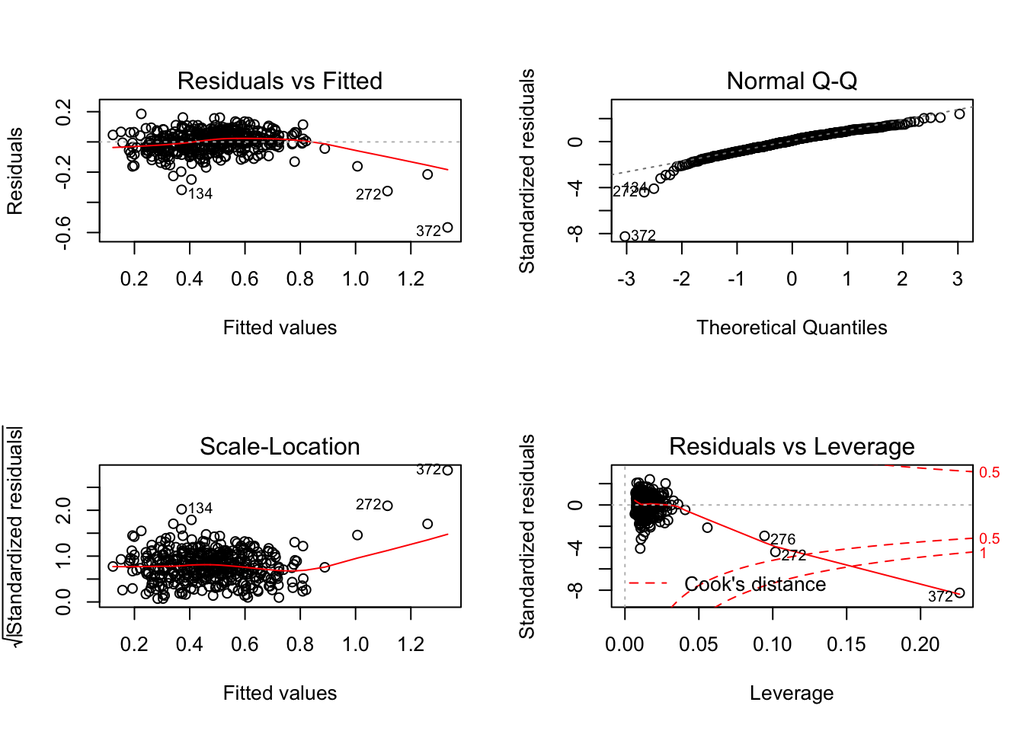

```r
fit <- lm(islaidosVaisiams~butinosIslaidos+pajamos+rajonoId+atstumasIkiParduotuves, data = data2)

par(mfrow = c(2,2))
plot(fit)
```

```r
outlierTest(fit)
```

```
##      rstudent unadjusted p-value Bonferonni p
## 372 -9.036792         6.8125e-18   2.7931e-15
## 272 -4.505175         8.6997e-06   3.5669e-03
## 134 -4.176178         3.6360e-05   1.4908e-02
```

```r
which(is.na(data3))
```

```
## [1]   57  154  424 1131 1342
```

```r
data <- data2[-c(131,268,367),]#atsižvelgiame į pašalintas reikšmes
```

3. Duomenu apzvalga

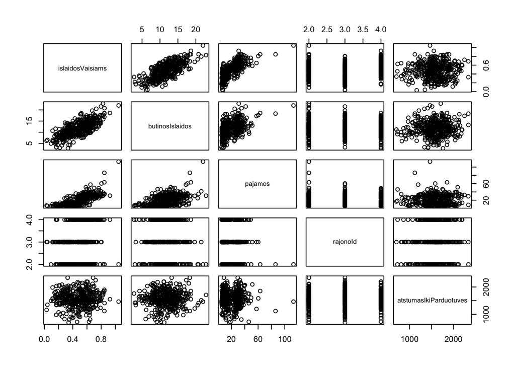

```r
attach(data)
plot(data)
```

```r
summary(data)
```

```
##  islaidosVaisiams  butinosIslaidos     pajamos        rajonoId
##  Min.   :0.03104   Min.   : 2.770   Min.   :  5.157      :  0
##  1st Qu.:0.34496   1st Qu.: 9.253   1st Qu.:  9.560   1  :131
##  Median :0.48921   Median :11.561   Median : 17.590   2  :153
##  Mean   :0.47807   Mean   :11.643   Mean   : 20.610   3  :123
##  3rd Qu.:0.60385   3rd Qu.:13.844   3rd Qu.: 29.706   NAN:  0
##  Max.   :1.04549   Max.   :22.843   Max.   :113.088
##  atstumasIkiParduotuves
##  Min.   : 700
##  1st Qu.:1409
##  Median :1568
##  Mean   :1570
##  3rd Qu.:1766
##  Max.   :2339
```

```r
cor(data$islaidosVaisiams, data$butinosIslaidos)
```

```
## [1] 0.729478
```

```r
cor(data$islaidosVaisiams, data$pajamos)
```

```
## [1] 0.7630099
```

```r
cor(data$butinosIslaidos,data$pajamos)
```

```
## [1] 0.4857474
```

**Padalinsime duomenis į trainset ir testset.** [šaltinis](https://stat.ethz.ch/pipermail/r-help/2005-November/082516.html%5D)

```r
sub <- sample(nrow(data), floor(nrow(data) * 0.8))
trainSet <- data[sub, ]
testSet <- data[-sub, ]
```

**2.**

**Sudarome tiesinį modelį.**

```r
modelis<- lm(islaidosVaisiams~butinosIslaidos+pajamos+rajonoId+atstumasIkiParduotuves, data = trainSet)
summary(modelis)
```

```
##
## Call:
## lm(formula = islaidosVaisiams ~ butinosIslaidos + pajamos + rajonoId +
##     atstumasIkiParduotuves, data = trainSet)
##
## Residuals:
##      Min       1Q   Median       3Q      Max
## -0.31702 -0.03767  0.00386  0.04108  0.18965
##
## Coefficients:
##                          Estimate Std. Error t value Pr(>|t|)
## (Intercept)             6.020e-03  2.248e-02   0.268    0.789
## butinosIslaidos         2.476e-02  1.185e-03  20.890  < 2e-16 ***
## pajamos                 8.120e-03  3.233e-04  25.119  < 2e-16 ***
## rajonoId2              -4.424e-02  8.403e-03  -5.265 2.58e-07 ***
## rajonoId3               9.767e-02  9.038e-03  10.807  < 2e-16 ***
## atstumasIkiParduotuves  2.812e-06  1.189e-05   0.236    0.813
## ---
## Signif. codes:  0 '***' 0.001 '**' 0.01 '*' 0.05 '.' 0.1 ' ' 1
##
## Residual standard error: 0.06333 on 319 degrees of freedom
## Multiple R-squared:  0.8785, Adjusted R-squared:  0.8766
## F-statistic: 461.1 on 5 and 319 DF,  p-value: < 2.2e-16
```

**Pašaliname nereikšmingus kintamuosius** kuriu p-value>0.05

```r
fit1 <- lm(islaidosVaisiams~butinosIslaidos+pajamos+rajonoId, data = trainSet)
summary(fit1)
```

```
##
## Call:
## lm(formula = islaidosVaisiams ~ butinosIslaidos + pajamos + rajonoId,
##     data = trainSet)
##
## Residuals:
##      Min       1Q   Median       3Q      Max
## -0.31828 -0.03771  0.00451  0.04100  0.18977
##
## Coefficients:
##                   Estimate Std. Error t value Pr(>|t|)
## (Intercept)      0.0101585  0.0140752   0.722    0.471
## butinosIslaidos  0.0247794  0.0011802  20.996  < 2e-16 ***
## pajamos          0.0081188  0.0003227  25.156  < 2e-16 ***
## rajonoId2       -0.0441501  0.0083811  -5.268 2.54e-07 ***
## rajonoId3        0.0978218  0.0090029  10.866  < 2e-16 ***
## ---
## Signif. codes:  0 '***' 0.001 '**' 0.01 '*' 0.05 '.' 0.1 ' ' 1
##
## Residual standard error: 0.06324 on 320 degrees of freedom
## Multiple R-squared:  0.8784, Adjusted R-squared:  0.8769
## F-statistic: 578.1 on 4 and 320 DF,  p-value: < 2.2e-16
```

Palyginkime modelius pagal AKAIKE kriterijų.

```r
AIC(fit1)
```

```
## [1] -865.2958
```

```r
AIC(modelis)
```

```
## [1] -863.3527
```

Pagal AKAIKE, matome, fit1 yra geriausias

**Patikriname dėl multikolinearumo.** Tinkama priemone patikrinti, ar modelyje egzistuoja multikolinearumo problema, yra Variance Inflation Factor (VIF). Jei kuris nors VIF koeficientas > 10, tai yra neblogas argumentas teigti, kad modelyje yra multikolinearumas.

```r
vif(fit1)
```

```
##                     GVIF Df GVIF^(1/(2*Df))
## butinosIslaidos 1.278380  1        1.130655
## pajamos         1.268244  1        1.126163
## rajonoId        1.012041  2        1.002997
```

Matome, kad multikolianerumo nera.

**Patikriname dėl heteroskedastiškumo.**

```r
ncvTest(fit1)
```

```
## Non-constant Variance Score Test
## Variance formula: ~ fitted.values
## Chisquare = 7.070584    Df = 1     p = 0.007835969
```

ncvTest funkcija atlieka testą su nuline hipoteze, kad modelis homoskedastiškas ir alternatyva, kad modelis heteroskedastiškas.

p-value < 0.05, todėl atmetame H0, tai reiškia modelis yra heteroskedastiškas. Kintamųjų koeficientų įvertinių dispersijos yra paslinktos, todėl ir kintamųjų p-value gali būti neteisingos. Vadinasi, negalime įvertinti kintamųjų tinkamai. Todėl pasinaudosime White’o korekcija, kuri pataisys paklaidas ir p-value.

```r
library(lmtest)
coeftest(fit1, vcov= hccm(fit1)) # jei modelis heteroskedastiskas jis pataiso p-value
```

```
##
## t test of coefficients:
##
##                    Estimate  Std. Error t value  Pr(>|t|)
## (Intercept)      0.01015851  0.01597273  0.6360    0.5252
## butinosIslaidos  0.02477940  0.00120077 20.6363 < 2.2e-16 ***
## pajamos          0.00811879  0.00059335 13.6829 < 2.2e-16 ***
## rajonoId2       -0.04415006  0.00872266 -5.0615  7.03e-07 ***
## rajonoId3        0.09782183  0.00945636 10.3446 < 2.2e-16 ***
## ---
## Signif. codes:  0 '***' 0.001 '**' 0.01 '*' 0.05 '.' 0.1 ' ' 1
```

**Patikriname paklaidų normalumą.** (http://stats.stackexchange.com/questions/100214/assumptions-of-linear-models-and-what-to-do-if-the-residuals-are-not-normally-di)

```r
res <- as.vector(fit1$residuals)
shapiro.test(res)
```

```
##
##  Shapiro-Wilk normality test
##
## data:  res
## W = 0.9756, p-value = 2.526e-05
```

shapiro.test funkcija patvirtina atmete nulinę hipotezę, kad modelio liekanos išsidėsčiusios pagal normalųjį skirstinį (p-value < 0.05). Liekanos neissidesciusios normaliai. Yra tikimybe, kad priklausomybes tarp Y ir X’su, bet kartais si salyga gali buti netenkinamo todel ja ignoriusiu.

**3.**

**Išbrėžiame 2 sklaidos diagramas, kaip reikalauja sąlyga**

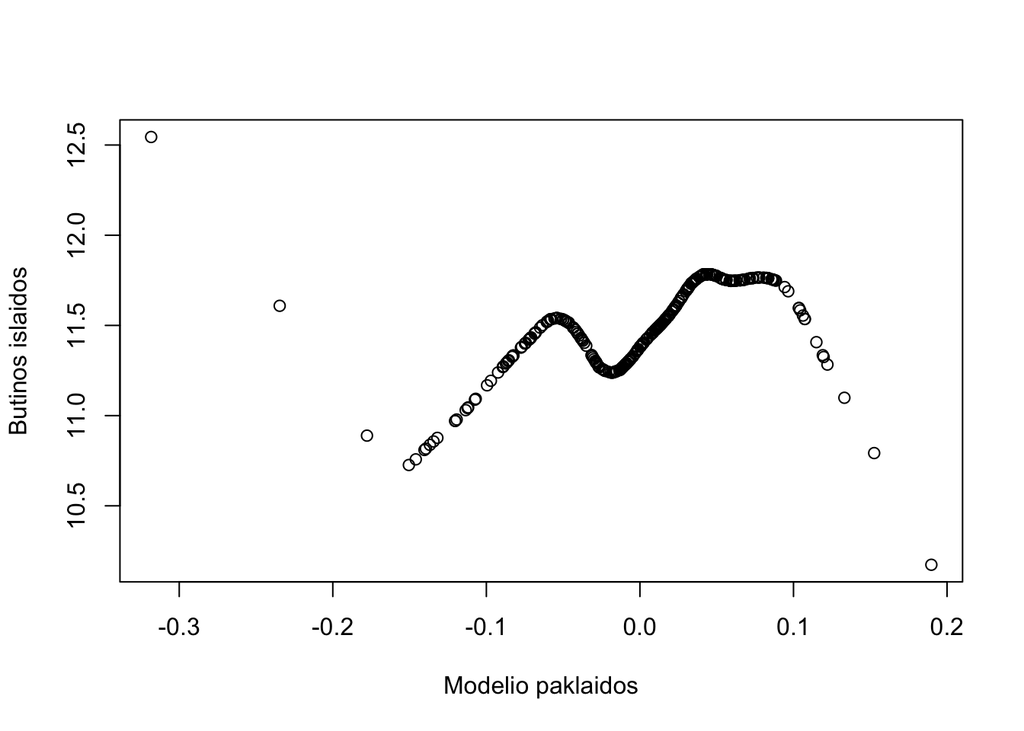

```r
par(mfrow = c(1,1))
plot(lowess(fit1$res,trainSet$butinosIslaidos), ylab = "Butinos islaidos", xlab = "Modelio paklaidos")
```

Tai nepanasu i tiesine priklausomybe tarp modelio paklaidu ir butinu islaidu

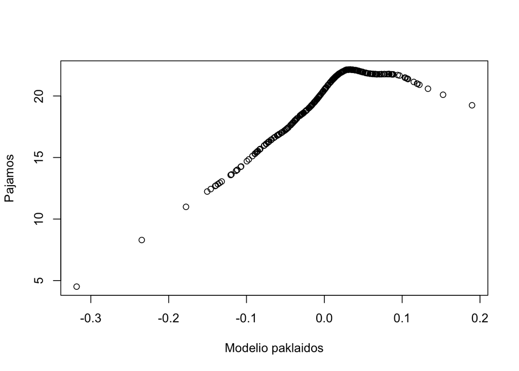

```r
par(mfrow = c(1,1))
plot(lowess(fit1$res,trainSet$pajamos), ylab = "Pajamos", xlab = "Modelio paklaidos")
```

Ganetinai panasu i tiesine priklausomybe iki tam tikro tasko tarp pajamu ir modelio paklaidu.

2. Bandysime logaritumuoti, galbut tai pades duomenis padaryti tiesiskesniais.

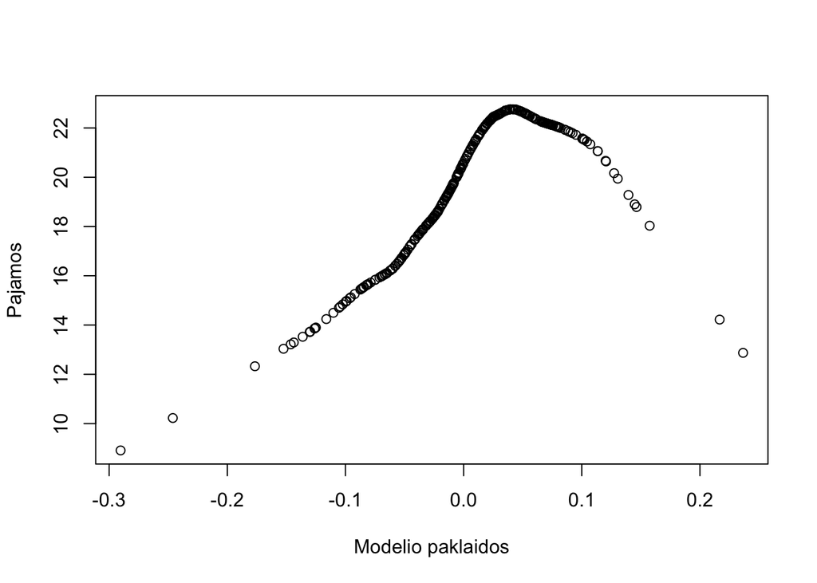

```r
fit2 <- lm(islaidosVaisiams~log(butinosIslaidos)+pajamos+rajonoId, data = trainSet)

plot(lowess(fit2$res,trainSet$pajamos), ylab = "Pajamos", xlab = "Modelio paklaidos")
```

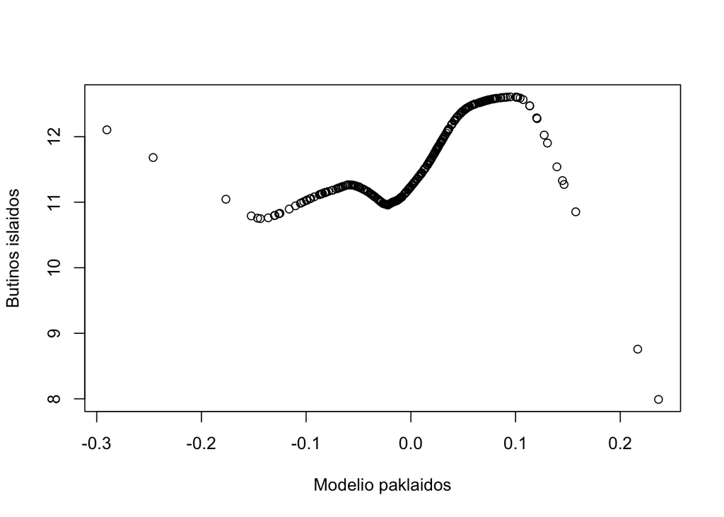

```r
plot(lowess(fit2$res,trainSet$butinosIslaidos), ylab = "Butinos islaidos", xlab = "Modelio paklaidos")
```

Skaida logaritmave padareme tiesiskesne

**4.**

```r
fit11 <- lm(islaidosVaisiams~butinosIslaidos+pajamos+rajonoId, data = testSet)
fit22 <- lm(islaidosVaisiams~log(butinosIslaidos)+pajamos+rajonoId, data = testSet)

mse1 <- sum((fit1$res)^2)/length(fit1$res)
mse2 <- sum((fit2$res)^2)/length(fit2$res)
mse3 <- sum((fit11$res)^2)/length(fit11$res)
mse4 <- sum((fit22$res)^2)/length(fit22$res)
```

**Rezultatų lentelė**

```r
Modeliai <- c("fit1", "fit2")
MSEtrainSet <- c(mse1, mse2)
MSEtestSet <- c(mse3, mse4)
data.frame(Modeliai, MSEtrainSet, MSEtestSet)
```

```
##   Modeliai MSEtrainSet  MSEtestSet
## 1     fit1 0.003937345 0.004621056
## 2     fit2 0.004342040 0.004466174
```

Matome, kad fit1 geriau suveike su trainset, o fit2 su testset Teikciau pirmenybe fit2 modeliui, jis atrodo stabilesnis nes ir skirtumas tarp testset ir trainset yra mazesnis nei fit1

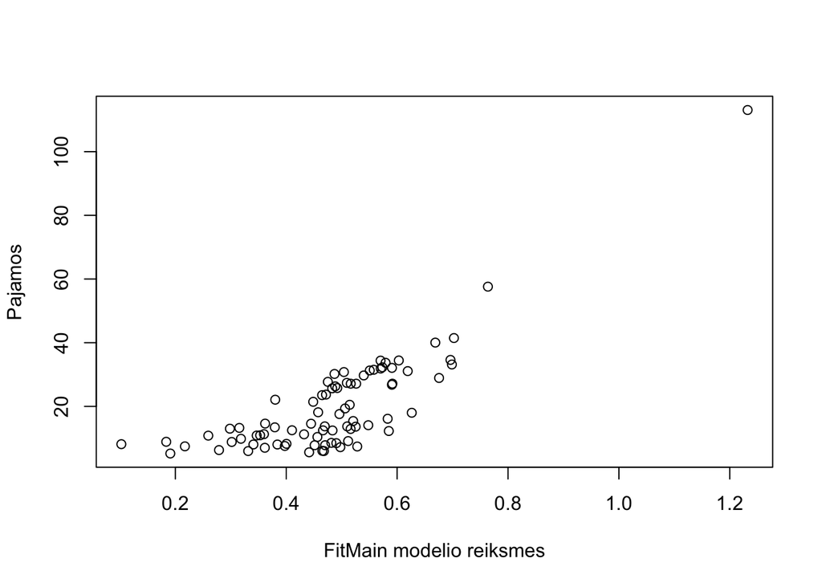

```r
fitMain<- fit22

plot(predict(fitMain),testSet$pajamos, ylab = "Pajamos", xlab = "FitMain modelio reiksmes")
```

# 3 užduotis

**Įsirašome duomenis**

```r
library(dynlm)
data <- M1Germany
```

**Sudarome modelį**

```r
mod1 <- dynlm(data$logprice~L(data$loggnp, 1)+d(L(data$loggnp, 2))) #nezinau kaip prideti sezonine kimoinente

summary(mod1)
```

```
##
## Time series regression with "zooreg" data:
## Start = 1960 Q4, End = 1996 Q1
##
## Call:
## dynlm(formula = data$logprice ~ L(data$loggnp, 1) + d(L(data$loggnp,
##     2)))
##
## Residuals:
##      Min       1Q   Median       3Q      Max
## -0.18535 -0.06962 -0.01279  0.06643  0.26184
##
## Coefficients:
##                       Estimate Std. Error t value Pr(>|t|)
## (Intercept)          -11.06151    0.34114  -32.42   <2e-16 ***
## L(data$loggnp, 1)      1.71053    0.03837   44.58   <2e-16 ***
## d(L(data$loggnp, 2))  -0.26488    0.15577   -1.70   0.0913 .
## ---
## Signif. codes:  0 '***' 0.001 '**' 0.01 '*' 0.05 '.' 0.1 ' ' 1
##
## Residual standard error: 0.1055 on 139 degrees of freedom
## Multiple R-squared:  0.9349, Adjusted R-squared:  0.9339
## F-statistic: 997.7 on 2 and 139 DF,  p-value: < 2.2e-16
```

**Gauname jo liekanas**

```r
ser<-ts(mod1$residuals,start=c(1960,1), frequency = 4)
```

**Išbrėžiame liekanų grafiką**

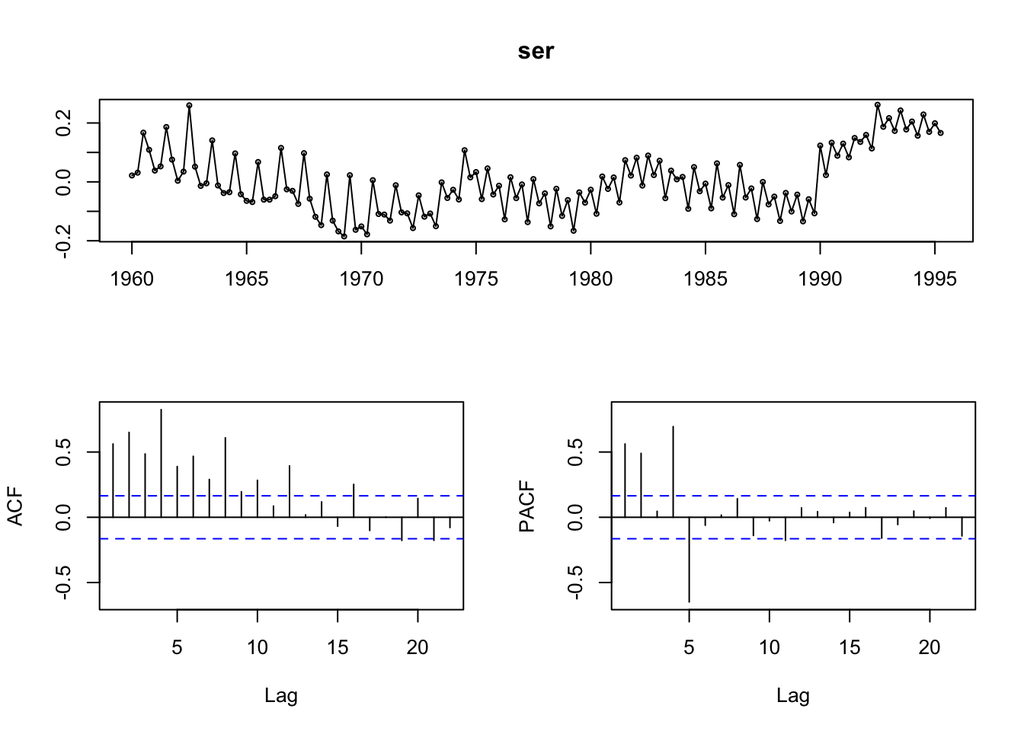

```r
tsdisplay(ser)
```

**Šaliname sezoniškumą:** **I būdas**

```r
stl <- stl(ser, s.window="periodic")
pbudas <- ser - stl$time.series[,"seasonal"]
ser <- pbudas
```

**Tikriname stacionarumą**

```r
n <- ndiffs(ser)
n#diferencijavimo eilė
```

```
## [1] 1
```

```r
ser <- diff(ser, diff = n)
```

```r
kpss.test(ser)
```

```
##
##  KPSS Test for Level Stationarity
##
## data:  ser
## KPSS Level = 0.1605, Truncation lag parameter = 2, p-value = 0.1
```

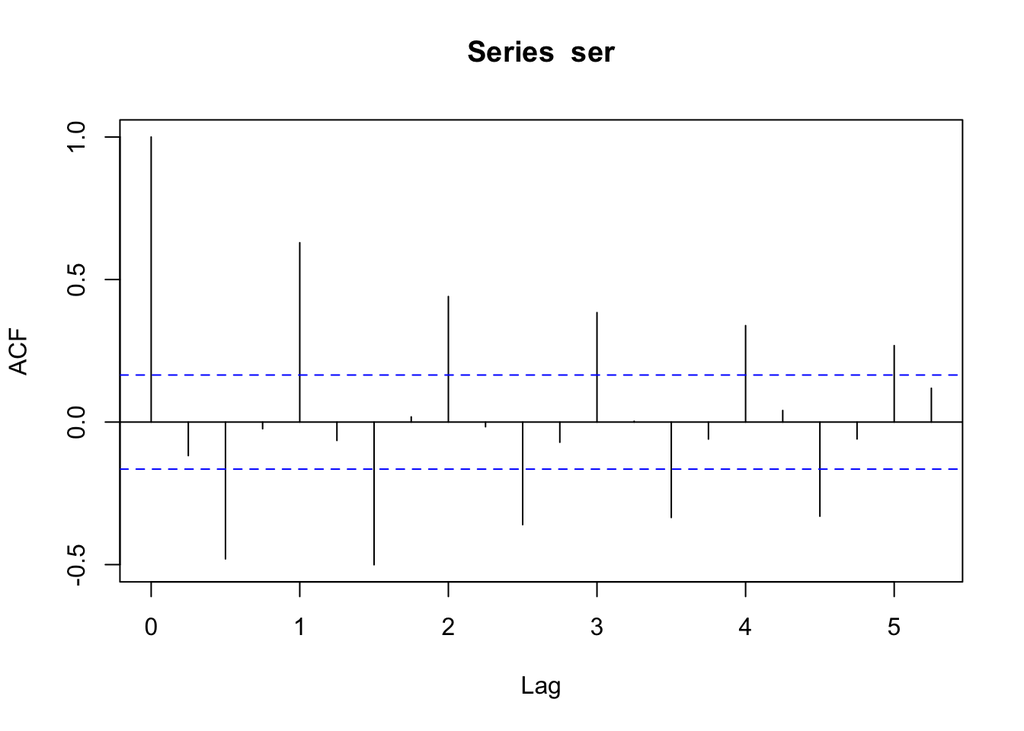

```r
acf(ser) # pagal acf atrodo nestacionaru nes uzgesta labai letai
```

p-value > 0.05, priimame H0, duomenys stacionarus. Teigciau kad duomenys nestacionarus

**Tikriname, ar reikia Box-Cox transformacijos**

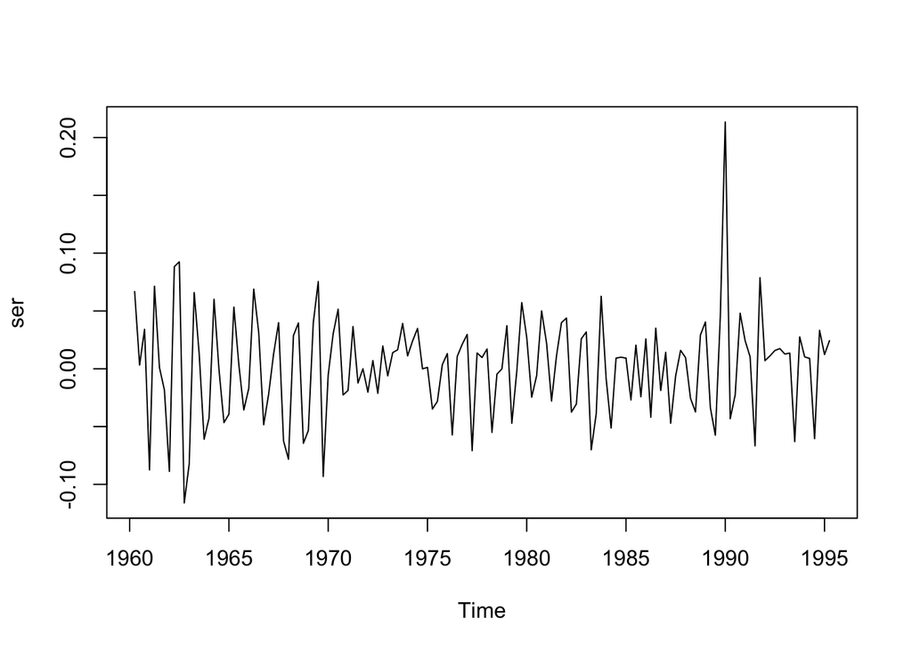

```r
plot(ser)
```

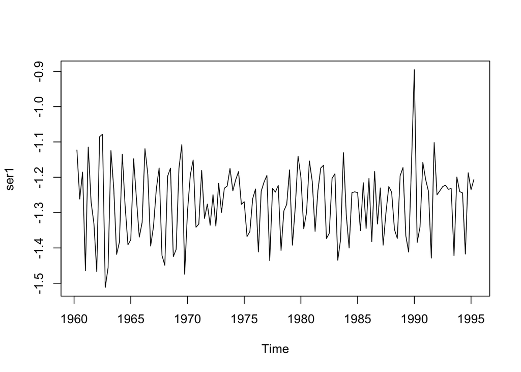

```r
lambd <- BoxCox.lambda(ser)#randame Box-Cox transformacijos parametrą lambda
ser1 <- BoxCox(ser,lambda = lambd)
plot(ser1)
```

Box-cox transformacija reikalinga nes priartina visus svyrazimus prie ryskesniu issisokimu.

2 dalis

**Panaudojama ets funkcija randame siūlomą eksponentinio glodinimo modelį**

```r
mod1<-ets(ser1)
mod1[13]
```

```
## $method
## [1] "ETS(A,N,A)"
```

ETS (A,N,A) (aditive level,none trend,aditive season)

**Randame kitas dvi alternatyvas**

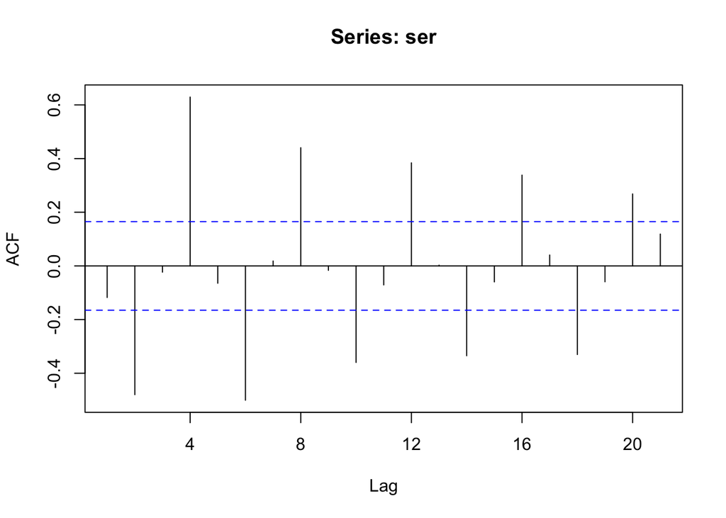

```r
Acf(ser)
```

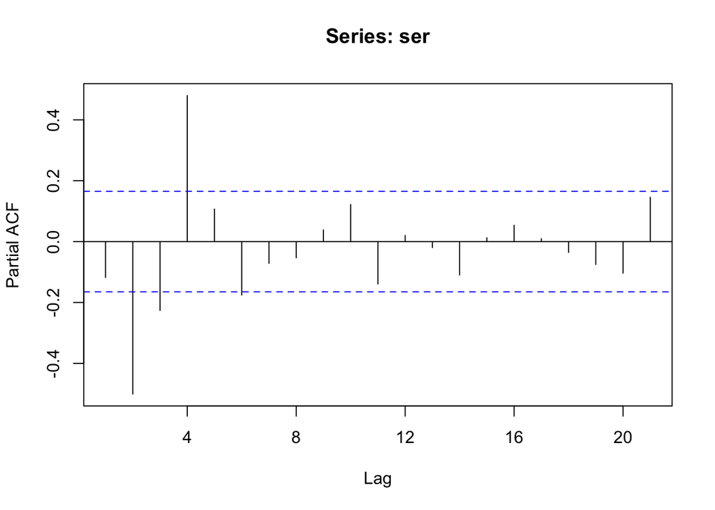

```r
Pacf(ser)
```

```r
fitas1 <- Arima(ser, order = c(5,0,0))
fitas2 <- hw(ser)
```

Iš ACF ir PACF grafikų matome, kad tikėtini modeliai gali būti ARIMA(5,0,0) (pagal “Forecasting - Principles and Practice” [Hyndman 2014], 76 psl.), taip pat pasirinkime Holt-Winters metodą.

**Palyginkime visus 3 modelius pagal RMSE**

```r
accuracy(mod1)[2]
```

```
## [1] 0.07381242
```

```r
accuracy(fitas1)[2]
```

```
## [1] 0.03199803
```

```r
accuracy(fitas2)[2]
```

```
## [1] 0.0346417
```

```r
mod2 <- Arima(ser, order = c(5,0,0))
```

Nuo mod1 šis modelis skiriasi tuom, kad šiam modeliui sukurti naudojama ARIMA, o mod1 naudojome ETS.

**Pritaikome auto.arima**

```r
auto.arima(ser)
```

```
## Series: ser
## ARIMA(2,0,2)(1,0,2)[4] with zero mean
##
## Coefficients:
##          ar1      ar2      ma1     ma2     sar1    sma1    sma2
##       0.0523  -0.9751  -0.1727  0.8969  -0.4036  0.7729  0.2086
## s.e.  0.0245   0.0263   0.0491  0.0724   0.7822  0.7633  0.2598
##
## sigma^2 estimated as 0.0009822:  log likelihood=286.64
## AIC=-557.27   AICc=-556.18   BIC=-533.68
```

```r
mod3 <- auto.arima(ser)
```

ARIMA(p,d,q)(P,D,Q)[m] p,d,q - nonseasonal part of the model P,D,Q - seasonal part of the model AR: p, P = order of the autoregressive part I: d, D = degree of first differencing involved MA: q, Q = order of the moving average part m - number of periods per season.

**Sukurkime dar 2 modelius**

```r
fit1 <- Arima(ser, order=c(2,0,0), seasonal=list(order=c(1,0,0),period=4))
fit2 <- Arima(ser, order=c(2,1,2), seasonal=list(order=c(2,0,0),period=4))
```

**Palyginkime visus 3 modelius pagal RMSE**

```r
accuracy(mod3)[2]
```

```
## [1] 0.03133989
```

```r
accuracy(fit1)[2]
```

```
## [1] 0.03311665
```

```r
accuracy(fit2)[2]
```

```
## [1] 0.03270179
```

```r
mod4 <- Arima(ser, order=c(2,1,2), seasonal=c(2,0,0))
```

**Patikriname visų 4 modelių liekanas**

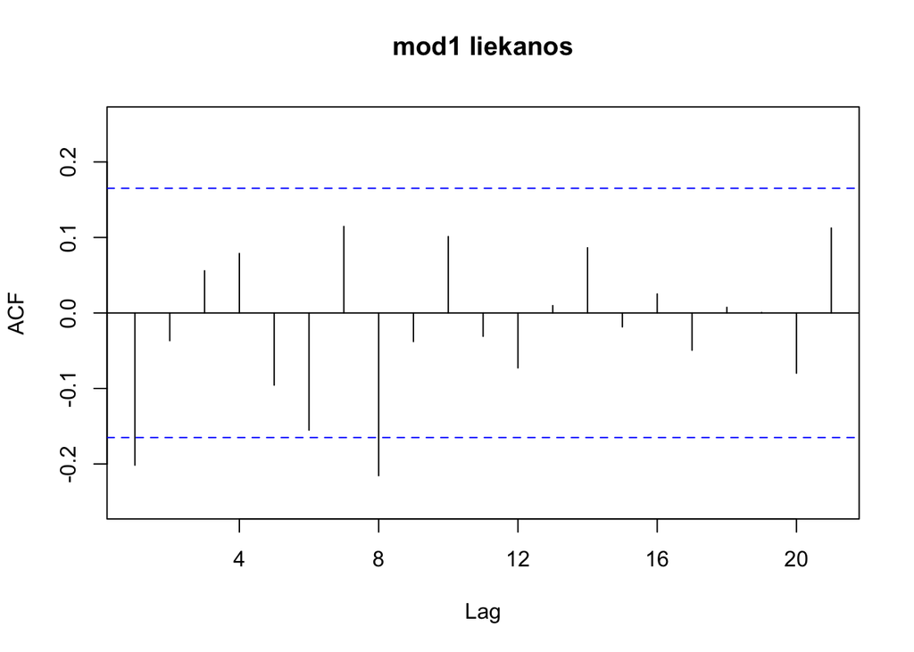

```r
Acf(mod1$res, main = "mod1 liekanos")
```

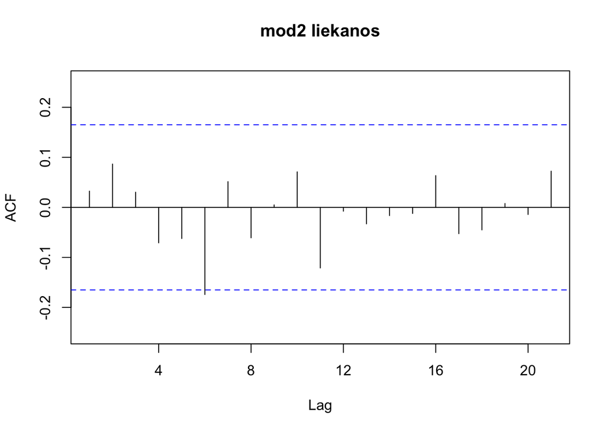

```r
Acf(mod2$res, main = "mod2 liekanos")
```

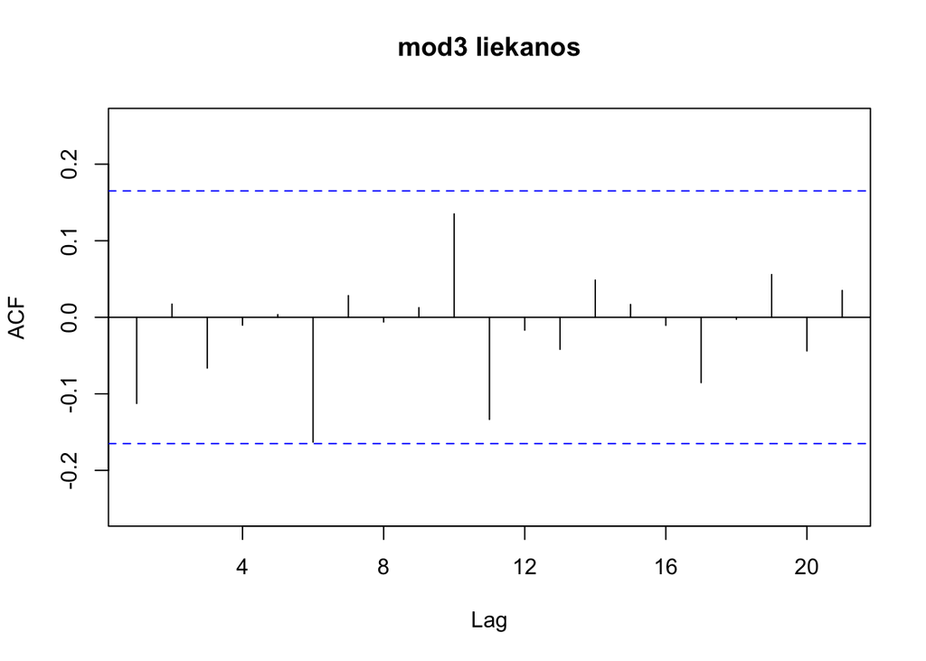

```r
Acf(mod3$res, main = "mod3 liekanos")
```

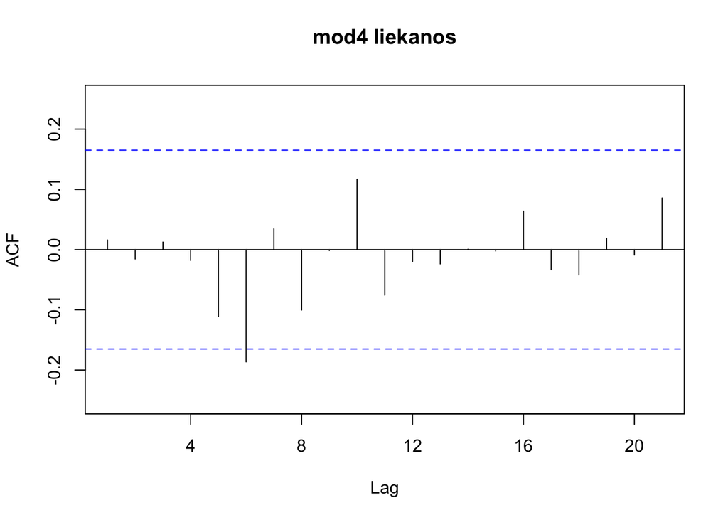

```r
Acf(mod4$res, main = "mod4 liekanos")
```

```r
Box.test(mod1$res, type="Lj")
```

```
##
##  Box-Ljung test
##
## data:  mod1$res
## X-squared = 5.8499, df = 1, p-value = 0.01558
```

```r
Box.test(mod2$res, type="Lj")
```

```
##
##  Box-Ljung test
##
## data:  mod2$res
## X-squared = 0.1518, df = 1, p-value = 0.6968
```

```r
Box.test(mod3$res, type="Lj")
```

```
##
##  Box-Ljung test
##
## data:  mod3$res
## X-squared = 1.8245, df = 1, p-value = 0.1768
```

```r
Box.test(mod4$res, type="Lj")
```

```
##
##  Box-Ljung test
##
## data:  mod4$res
## X-squared = 0.0369, df = 1, p-value = 0.8477
```

**ser padaliname į trainSet ir testSet**

```r
trainSet <- window(ser, end = c(1987,4))
testSet <- window(ser, start = c(1988, 1))
```

**Įvertiname visus 4 modelius naudodami trainSet**

```r
mod11 <- ets(trainSet)
mod22 <- Arima(trainSet, order = c(5,0,0))
mod33 <- auto.arima(trainSet)
mod44 <- Arima(trainSet, order=c(2,1,2), seasonal=c(1,0,0))
```

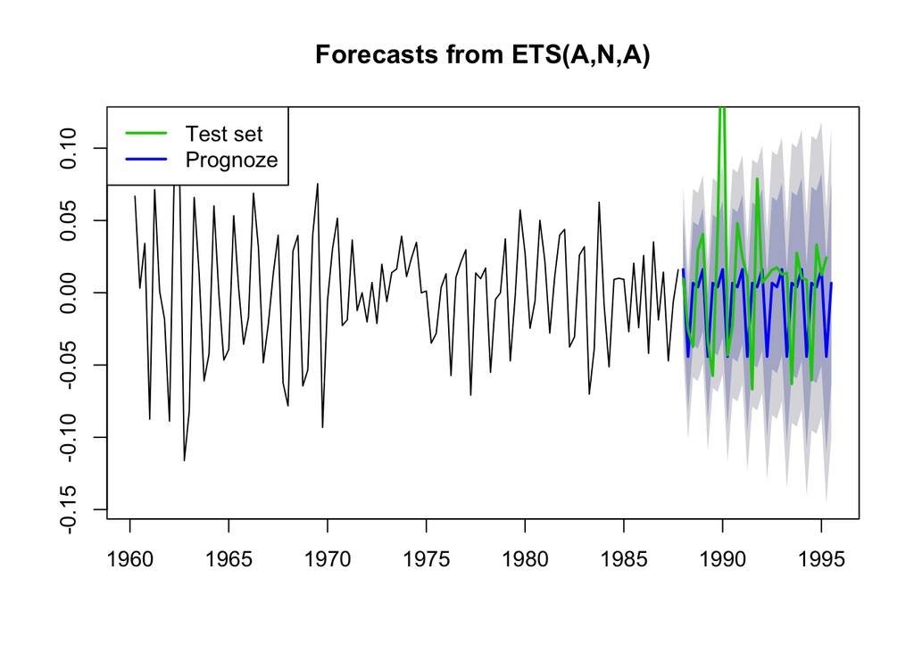

```r
plot(forecast(mod11, h=31))
lines(testSet, lwd=2, col=3)
legend("topleft",lty=1,lwd="2",col=c(3,4),legend=c("Test set","Prognoze"))
```

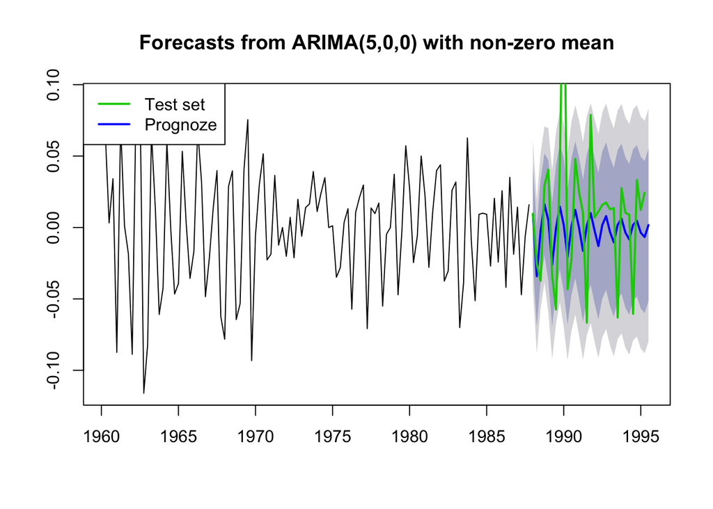

```r
plot(forecast(mod22, h=31))
lines(testSet, lwd=2, col=3)
legend("topleft",lty=1,lwd="2",col=c(3,4),legend=c("Test set","Prognoze"))
```

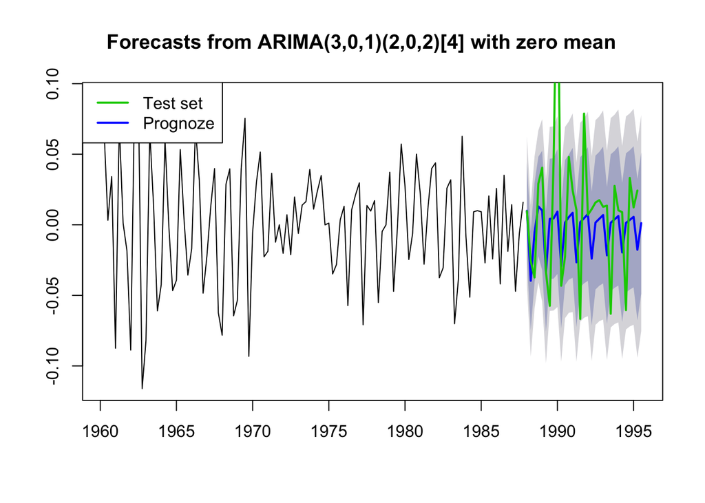

```r
plot(forecast(mod33, h=31))
lines(testSet, lwd=2, col=3)
legend("topleft",lty=1,lwd="2",col=c(3,4),legend=c("Test set","Prognoze"))
```

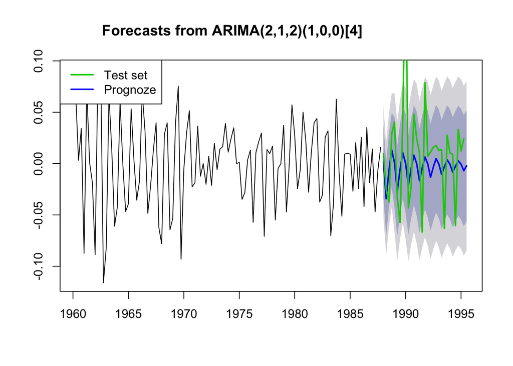

```r
plot(forecast(mod44, h=31))
lines(testSet, lwd=2, col=3)
legend("topleft",lty=1,lwd="2",col=c(3,4),legend=c("Test set","Prognoze"))
```

**Patikrinsime visų modelių tikslumą su funkcija accuracy.**

```r
f1 <- forecast(mod11, h=31)
f2 <- forecast(mod22, h=31)
f3 <- forecast(mod33, h=31)
f4 <- forecast(mod44, h=31)
accuracy(f1, testSet)
```

```
##                        ME       RMSE        MAE        MPE      MAPE
## Training set 4.317201e-05 0.02894881 0.02154110 -3398.0677 4537.8984
## Test set     1.439191e-02 0.05482538 0.03949051   115.0201  143.0113
##                   MASE       ACF1 Theil's U
## Training set 0.9561775 -0.1899412        NA
## Test set     1.7529246 -0.2936684  1.228772
```

```r
accuracy(f2, testSet)
```

```
##                        ME       RMSE        MAE       MPE      MAPE
## Training set 0.0002844254 0.02652678 0.02038630 -978.2524 1793.1540
## Test set     0.0112957594 0.05085561 0.03400721  100.3113  102.5464
##                   MASE        ACF1 Theil's U
## Training set 0.9049173  0.03745454        NA
## Test set     1.5095292 -0.15779474 0.9204816
```

```r
accuracy(f3, testSet)
```

```
##                         ME       RMSE        MAE       MPE      MAPE
## Training set -0.0004974266 0.02683350 0.02049664 -631.7625 1362.2041
## Test set      0.0128030849 0.05124041 0.03467058  101.3303  105.8025
##                   MASE       ACF1 Theil's U
## Training set 0.9098154  0.0188418        NA
## Test set     1.5389756 -0.2036955 0.9908791
```

```r
accuracy(f4, testSet)
```

```
##                        ME       RMSE        MAE       MPE      MAPE
## Training set -0.001615949 0.02754183 0.02111056 -161.1765 1413.7760
## Test set      0.013362918 0.05071392 0.03404643  101.1607  103.4124
##                   MASE        ACF1 Theil's U
## Training set 0.9370662  0.02242849        NA
## Test set     1.5112703 -0.16264159 0.8841109
```

```r
modMain <- Arima(trainSet, order = c(5,0,0))
```